Field notes · Remote sensing · Australian fire

# Can a small deep model beat a twenty-year-old spectral index, without pretending the labels are truth?

A retrospective burn-severity benchmark over four 2019–2020 Black Summer fire events in Australia, comparing five methods on Sentinel-2 imagery, with a careful look at where each one fails.

Ahmad Jaradat · Hobart, Tasmania · 2026

## The Black Summer left scars you can see from orbit

Between July 2019 and March 2020, fires across south-eastern Australia burned roughly **12.6 million hectares** of temperate forest, killed or displaced an estimated **3 billion vertebrates** (mammals, reptiles, birds, frogs), claimed **33 lives directly** and a further **417 attributed to smoke**, and inflicted at least **A$10 billion** in damages, the country's most catastrophic bushfire season in modern record [^1] [^2] [^3].

About **1.8 million hectares** of that burnt at *high severity*, meaning canopy loss across the great majority of trees [^4]. That distinction, between fire passing through and fire consuming, matters for ecological recovery, insurance, hydrology, post-fire erosion risk, and biodiversity triage. It is also the part hardest to measure.

[^1]: Filkov, A.I., Ngo, T., Matthews, S., Telfer, S. & Penman, T.D. (2020). *Impact of Australia's catastrophic 2019/20 bushfire season on communities and environment*. **Journal of Safety Science and Resilience**, 1(1). [DOI](https://www.sciencedirect.com/science/article/pii/S2666449620300098) [^2]: Department of Climate Change, Energy, the Environment and Water (DCCEEW). *Bushfire Impacts portal*. [Link](https://www.dcceew.gov.au/environment/biodiversity/bushfire-recovery/bushfire-impacts) [^3]: Dickman, C. *et al.* (2020) for WWF Australia. *Australia's 2019–2020 Bushfires: The Wildlife Toll*. [Link](https://wwf.org.au/news/2020/3-billion-animals-impacted-by-australia-bushfire-crisis/) [^4]: Collins, L. *et al.* (2021). *A staggering 1.8 million hectares burned in high-severity fires*. Summary of [Nature Climate Change paper](https://theconversation.com/a-staggering-1-8-million-hectares-burned-in-high-severity-fires-during-australias-black-summer-157883).

### Why satellites can see what we cannot

Healthy vegetation has a peculiar optical signature. Chlorophyll absorbs red light, the spongy mesophyll of intact leaves scatters near-infrared (NIR) light efficiently, and water in living plant tissue absorbs short-wave infrared (SWIR). Together this produces the “red edge”, a sharp jump in reflectance between 0.7 and 0.8 µm that has no analogue in the rocks and soil underneath.

When fire passes through, water is driven out of the canopy, leaves crisp into char, and exposed soil and ash become visible to the satellite. **NIR reflectance collapses**; **SWIR2 reflectance rises** because dry ash absorbs less of the 2.0–2.3 µm band than living foliage did. The contrast between these two bands is what the **Normalised Burn Ratio** captures:

$$\mathrm{NBR} = \frac{B_{08} - B_{12}}{B_{08} + B_{12}}$$

where $B_{08}$ is Sentinel-2's NIR band (842 nm) and $B_{12}$ is its SWIR2 band (2190 nm). The differenced index from before and after the fire,

$$\Delta\mathrm{NBR} = \mathrm{NBR}_{\text{pre}} - \mathrm{NBR}_{\text{post}}\;,$$

is positive where vegetation was healthy and is no longer, and is larger where the damage was more severe [^5]. The whole project rests on this physical observation.

[^5]: Key, C. & Benson, N. (2006). *Landscape Assessment (LA): Sampling and Analysis Methods*. FIREMON GTR-RMRS-164-CD, USDA Forest Service. [Treesearch link](https://research.fs.usda.gov/treesearch/24066)

```python
# --- Imports + theme ----------------------------------------------------------
import os, sys, json
from pathlib import Path

import numpy as np
import pandas as pd
import matplotlib.pyplot as plt
from matplotlib.patches import Rectangle
from matplotlib.gridspec import GridSpec

# Make src.* importable when running the notebook from notebooks/
REPO_ROOT = Path.cwd().parent if Path.cwd().name == 'notebooks' else Path.cwd()
sys.path.insert(0, str(REPO_ROOT))

from src.viz.theme import (apply_theme, figure, thin_axes, add_caption,
                           severity_legend, severity_cmap, dnbr_cmap,
                           SEVERITY_COLOURS, SEVERITY_NAMES, MODEL_COLOURS,
                           PAPER, INK, INK_LIGHT, ACCENT, ACCENT_BLUE,
                           SEV_UNBURNT, SEV_LOW_MOD, SEV_HIGH, SEV_VERY_HIGH)
from src.viz.scene_loader import load_kangaroo, model_predictions
from src.viz.synthetic_scene import s2_truecolour, s2_swir_falsecolour
from src.features.indices import nbr
from src.evaluation.metrics import summary, binary_summary, confusion_matrix
from src.models.baselines import dnbr as dnbr_index, dnbr_multiclass_usgs

apply_theme()

# Try real first; fall back to synthetic if data hasn't been fetched yet.
scene = load_kangaroo()
SOURCE_BADGE = ('REAL, Sentinel-2 + AUS GEEBAM' if scene.is_real
                else 'SYNTHETIC stand-in (run scripts/fetch_event_streamlined.py to use real)')
print(f'matplotlib {plt.matplotlib.__version__} ready · repo {REPO_ROOT.name}')
print(f'Scene: {SOURCE_BADGE}')
if scene.is_real:
    print(f'  CRS: {scene.crs}')
    print(f'  Pre  composite: {scene.n_pre_scenes} scenes, clear {100*scene.clear_fraction_pre:.0f}%')
    print(f'  Post composite: {scene.n_post_scenes} scenes, clear {100*scene.clear_fraction_post:.0f}%')
    print(f'  Image size: {scene.pre.shape}')
```

```
matplotlib 3.10.9 ready · repo Satellite_imageray_ML
Scene: REAL, Sentinel-2 + AUS GEEBAM
  CRS: EPSG:32753
  Pre  composite: 4 scenes, clear 74%
  Post composite: 3 scenes, clear 74%
  Image size: (6, 2317, 4270)
```

### The honest framing this notebook holds throughout

Burn-severity labels at continental scale are hard. There is no fleet of ecologists walking every paddock and ridge with quadrats. The Australian Government's national severity product, **AUS GEEBAM**, is itself derived from satellite indices, specifically a vegetation-stratified RNBR thresholded by IBRA bioregion [^6]. DCCEEW reports overall four-class agreement against state products of **48–82%**, improving to **72–92%** when the four classes are collapsed to two [^6].

Throughout this notebook, model performance is reported as **agreement with the GEEBAM proxy**, not as accuracy against ground truth. The distinction matters: any model that “matches GEEBAM perfectly” would mostly be learning GEEBAM's particular algorithmic choices, including its collapse of low and moderate severity into a single class. That is a useful technical bar, not a scientific endpoint.

[^6]: Department of Agriculture, Water and the Environment (now DCCEEW), 2020. *Australian Google Earth Engine Burnt Area Map: A rapid, national approach to fire severity*. [PDF](https://www.dcceew.gov.au/sites/default/files/env/pages/a8d10ce5-6a49-4fc2-b94d-575d6d11c547/files/ageebam.pdf)

## How to read this piece

This is a benchmark, but it is built as an *argument*. It opens with the physics that makes a burn scar visible from orbit, works up through five increasingly sophisticated models, and then spends most of its energy on the part that separates a senior result from a leaderboard entry: **finding out which of those models is actually better once you stop fooling yourself.** Nine stops, each one a figure you can act on.

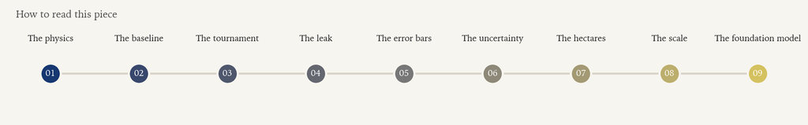

```python
# --- Roadmap: the argument in nine stops --------------------------------------
from src.viz.story_figures import fig_journey
from IPython.display import Image, display

_FIGDIR = REPO_ROOT / "docs" / "figures"
fig_journey(_FIGDIR / "00_journey.png")
display(Image(filename=str(_FIGDIR / "00_journey.png")))
```

### The bottom line, up front

If you read only one figure in this entire notebook, read the next one. It is the whole result on a single pair of axes: every method scored on a fire **none of them trained on**, with error bars that take spatial autocorrelation seriously. Most of the apparent winners turn out to *tie* a spectral index published in 1996. Exactly one does not.

*New to “event-wise hold-out”, the “spatial-block bootstrap”, or “Prithvi”? Don't worry, every term is unpacked below. This is the destination; the rest of the piece is the road to it.*

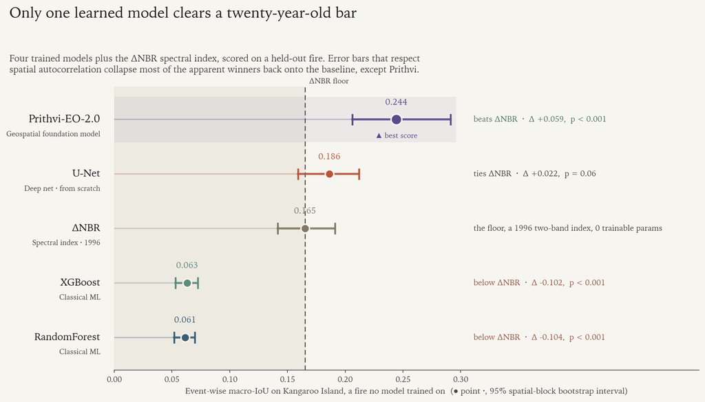

```python
# --- The bottom line: every method on a held-out fire, with honest error bars -
from src.viz.story_figures import fig_leaderboard

fig_leaderboard(_FIGDIR / "00_leaderboard.png")
display(Image(filename=str(_FIGDIR / "00_leaderboard.png")))
```

Three things to take from it. The two **classical models collapse** far below the baseline, pixel-wise classifiers had memorised the look of one fire, not the physics of burning. The from-scratch **U-Net ties** the 1996 index: its apparent edge does not survive the error bars (*p* = 0.06). Only the frozen **Prithvi-EO-2.0 foundation model clears the bar** by a margin that does (Δ macro-IoU +0.06, *p* < 0.001), and it does so with a tenth of the trainable parameters and none of the hand-built change features the others are handed.

Everything below earns that chart: the imagery, the five-model tournament, the single methodological move that makes the comparison honest, and the uncertainty, hectares and cost analyses a working monitoring platform actually needs.

## Where to look, and at what

Four fire events anchor the benchmark, chosen to span ecological gradients (heath, sclerophyll forest, alpine ash), state agencies (NSW, VIC, SA), and fire-complex sizes (∼200,000 ha to ∼1.5 million ha). The train/validate/test split is **event-wise**: the model never sees the same fire in training and test.

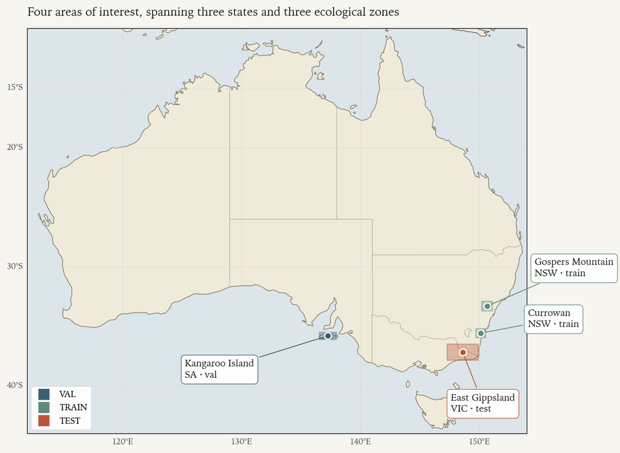

```python
# --- AOI locator map (cartopy + Natural Earth) -------------------------------
from src.viz.maps import render_aoi_locator
from IPython.display import Image, display
import tempfile

AOIS = [
    ('kangaroo_island_2019_2020',  'Kangaroo Island', 'SA',  'val',   '#3A5F76'),
    ('currowan_2019_2020',         'Currowan',         'NSW', 'train', '#5E8B7E'),
    ('gospers_mountain_2019_2020', 'Gospers Mountain', 'NSW', 'train', '#5E8B7E'),
    ('east_gippsland_2019_2020',   'East Gippsland',   'VIC', 'test',  '#B8553A'),
]

_out = REPO_ROOT / 'docs' / 'figures' / '01_aoi_locator.png'
render_aoi_locator(AOIS, _out, figsize=(11, 8))
display(Image(filename=str(_out)))
```

## The signal is visible before any model touches it

Below is one Sentinel-2 scene over Kangaroo Island from before the fires (October 2019) and one from after (January 2020). The shift on the western two-thirds of the island is unmistakable in true colour, the forest goes from green to a rusted brown, and it is even sharper in the SWIR-NIR false-colour composite used by fire ecologists, where burnt vegetation glows in shades of magenta and orange.

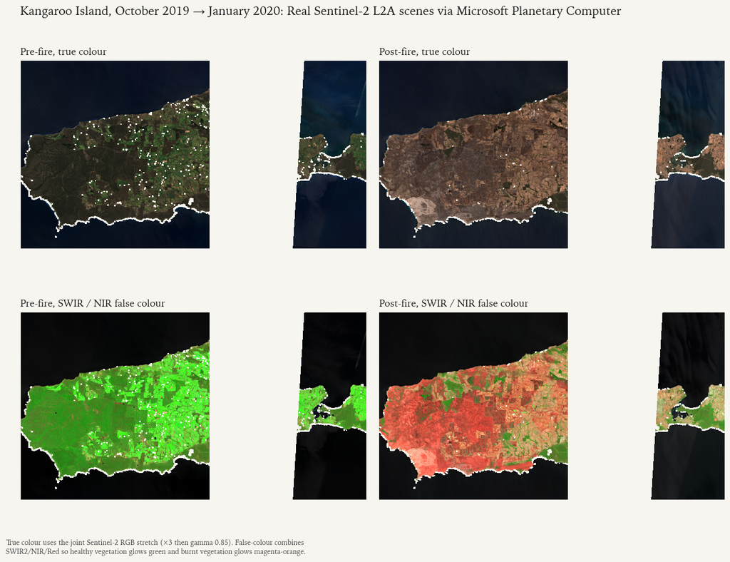

```python
# --- Pre / Post true colour + false colour ------------------------------------
pre_tc  = s2_truecolour(scene.pre)
post_tc = s2_truecolour(scene.post)
pre_fc  = s2_swir_falsecolour(scene.pre)
post_fc = s2_swir_falsecolour(scene.post)

fig, axes = plt.subplots(2, 2, figsize=(12.5, 9.0))
for ax in axes.ravel():
    ax.set_xticks([]); ax.set_yticks([])
    for s in ax.spines.values(): s.set_visible(False)
titles = [('Pre-fire, true colour',                    pre_tc),
          ('Post-fire, true colour',                   post_tc),
          ('Pre-fire, SWIR / NIR false colour',        pre_fc),
          ('Post-fire, SWIR / NIR false colour',       post_fc)]
for ax, (title, img) in zip(axes.ravel(), titles):
    ax.imshow(img); ax.set_title(title, loc='left', fontsize=12, color=INK, pad=8)

src_tag = ('Real Sentinel-2 L2A scenes via Microsoft Planetary Computer'
           if scene.is_real else 'Synthetic stand-in (deterministic seed=7)')
fig.suptitle(f'Kangaroo Island, October 2019 \u2192 January 2020: {src_tag}',
             fontsize=15, x=0.02, ha='left', y=0.99, color=INK)
fig.subplots_adjust(left=0.02, right=0.98, top=0.91, bottom=0.03, hspace=0.18, wspace=0.04)
add_caption(fig, 'True colour uses the joint Sentinel-2 RGB stretch (\u00d73 then gamma 0.85). False-colour combines\n'
                  'SWIR2/NIR/Red so healthy vegetation glows green and burnt vegetation glows magenta-orange.', y=-0.02)
plt.show()
```

### The spectral signature of fire, made visible

Before stacking up neural networks we should make sure the physics is doing what we think it is. The next figure shows a single horizontal transect across the burn boundary on Kangaroo Island. Pixel-by-pixel, we plot the reflectance of the four bands that matter most for burn detection, Red, NIR, SWIR1, SWIR2, both before and after the fire. The collapse in NIR and the rise in SWIR2 are not subtle. They are the optical signature that every classical and deep model in this notebook is, ultimately, trying to learn.

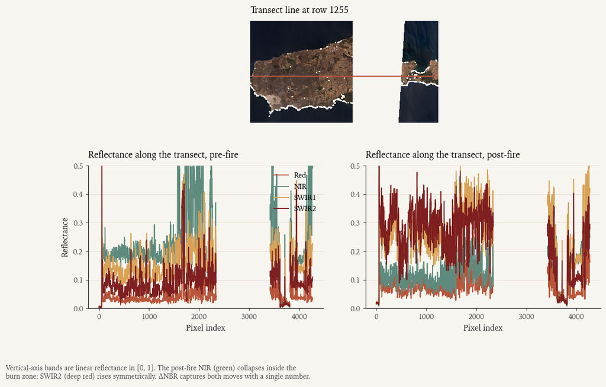

```python
# --- Reflectance transect across the burn boundary ----------------------------
# Pick a horizontal transect through the burn footprint
burn_rows = np.where(np.any(scene.burn_mask, axis=1))[0]
y_transect = int(np.mean(burn_rows)) if len(burn_rows) else scene.pre.shape[1] // 2
x = np.arange(scene.pre.shape[2])

fig = plt.figure(figsize=(11.5, 6.5))
gs = GridSpec(2, 2, height_ratios=[1.0, 1.4], hspace=0.35, wspace=0.18)
ax_map = fig.add_subplot(gs[0, :])
ax_map.imshow(post_tc)
ax_map.axhline(y=y_transect, color=ACCENT, linewidth=1.6)
ax_map.set_xticks([]); ax_map.set_yticks([])
for s in ax_map.spines.values(): s.set_visible(False)
ax_map.set_title(f'Transect line at row {y_transect}', loc='left', fontsize=11)

ax_pre  = fig.add_subplot(gs[1, 0])
ax_post = fig.add_subplot(gs[1, 1], sharey=ax_pre)
bands = [('Red',   2, '#B8553A'),
         ('NIR',   3, '#5E8B7E'),
         ('SWIR1', 4, '#D8A256'),
         ('SWIR2', 5, '#7F1F1F')]
for name, idx, c in bands:
    ax_pre.plot (x, scene.pre [idx, y_transect, :], color=c, linewidth=1.2, label=name)
    ax_post.plot(x, scene.post[idx, y_transect, :], color=c, linewidth=1.2, label=name)
ax_pre.set_title('Reflectance along the transect, pre-fire', loc='left', fontsize=11)
ax_post.set_title('Reflectance along the transect, post-fire', loc='left', fontsize=11)
ax_pre.set_ylim(0, 0.5); ax_pre.set_xlabel('Pixel index'); ax_pre.set_ylabel('Reflectance')
ax_post.set_xlabel('Pixel index')
ax_pre.legend(loc='upper right', fontsize=9, frameon=False)
thin_axes(ax_pre); thin_axes(ax_post)
add_caption(fig, 'Vertical-axis bands are linear reflectance in [0, 1]. The post-fire NIR (green) collapses inside the\n'
                  'burn zone; SWIR2 (deep red) rises symmetrically. \u0394NBR captures both moves with a single number.', y=-0.04)
plt.show()
```

## ΔNBR is a strong, explainable baseline

Aggregating that pixel-by-pixel story over the whole AOI gives the ΔNBR map. The signal is unambiguous: a coherent positive blob where the fire was, surrounded by low values where the vegetation was not affected. The conventional USGS thresholds [Key & Benson 2006] split this continuous map into four severity classes, and they do a respectable job, even though they were originally calibrated on US forests and have no Australian-eucalypt-specific tuning [^7].

[^7]: Boer, M.M. *et al.* (2008) document specifically the under-performance of plain dNBR in Western Australian eucalypts and propose ΔLAI. [DOI](https://www.sciencedirect.com/science/article/abs/pii/S0034425708002484). More recently, Rifai *et al.* (2024) show that pre-fire drought drives anomalous NBR baselines across Australian biomes, an open problem the field still grapples with. [AGU](https://agupubs.onlinelibrary.wiley.com/doi/10.1029/2023EF003780).

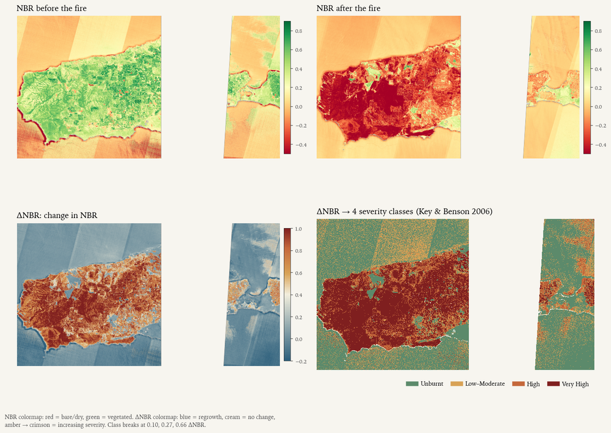

```python
# --- NBR / dNBR / thresholded multiclass --------------------------------------
nbr_pre  = nbr(scene.pre [3], scene.pre [5])
nbr_post = nbr(scene.post[3], scene.post[5])
d = dnbr_index(scene.pre, scene.post)
thresholded = dnbr_multiclass_usgs(d)
thresholded[~scene.land_mask] = 255

fig, axes = plt.subplots(2, 2, figsize=(12.5, 9.0))
for ax in axes.ravel():
    ax.set_xticks([]); ax.set_yticks([])
    for s in ax.spines.values(): s.set_visible(False)
im0 = axes[0,0].imshow(nbr_pre, cmap='RdYlGn', vmin=-0.5, vmax=0.9)
axes[0,0].set_title('NBR before the fire', loc='left', fontsize=12, pad=8)
im1 = axes[0,1].imshow(nbr_post, cmap='RdYlGn', vmin=-0.5, vmax=0.9)
axes[0,1].set_title('NBR after the fire', loc='left', fontsize=12, pad=8)
im2 = axes[1,0].imshow(d, cmap=dnbr_cmap(), vmin=-0.2, vmax=1.0)
axes[1,0].set_title('\u0394NBR: change in NBR', loc='left', fontsize=12, pad=8)
axes[1,1].imshow(np.ma.masked_equal(thresholded, 255),
                 cmap=severity_cmap(), vmin=0, vmax=3, interpolation='nearest')
axes[1,1].set_title('\u0394NBR \u2192 4 severity classes (Key & Benson 2006)', loc='left', fontsize=12, pad=8)
for ax, im in [(axes[0,0], im0), (axes[0,1], im1), (axes[1,0], im2)]:
    cb = fig.colorbar(im, ax=ax, fraction=0.038, pad=0.015, shrink=0.78)
    cb.outline.set_linewidth(0.5); cb.ax.tick_params(labelsize=8, color=INK_LIGHT)
handles = [plt.Rectangle((0, 0), 1, 1, color=c) for c in SEVERITY_COLOURS]
axes[1,1].legend(handles, SEVERITY_NAMES, loc='upper right',
                 bbox_to_anchor=(1.0, -0.04), ncols=4, fontsize=9,
                 frameon=False, columnspacing=1.2, handletextpad=0.4)
fig.subplots_adjust(left=0.02, right=0.98, top=0.94, bottom=0.07, hspace=0.22, wspace=0.08)
add_caption(fig, 'NBR colormap: red = bare/dry, green = vegetated. \u0394NBR colormap: blue = regrowth, cream = no change,\n'
                  'amber \u2192 crimson = increasing severity. Class breaks at 0.10, 0.27, 0.66 \u0394NBR.', y=-0.01)
plt.show()
```

## So what does machine learning add?

A reasonable reader looking at the ΔNBR map above might ask: *if a simple two-band ratio gets you something this good, why train a U-Net at all?*

Three reasons are honest:

1. **Thresholds drift across biomes.** What separates “low” from “moderate” severity in Californian chaparral is wrong for stringybark, and wrong again for alpine ash. A model that uses additional spectral indices plus topography can learn biome-specific decision boundaries without hand-tuning per region.
2. **Texture matters.** Convolutional and transformer models see neighbourhoods, not just pixels. A 10-metre pixel that looks ambiguous on its own often becomes unambiguous when the surrounding 30 pixels are also dark and SWIR-rich.
3. **Calibration.** A model that outputs a probability, and gets that probability *right* on average, is a much more useful operational input than a hard four-class assignment. We measure this with a reliability diagram further down.

What follows is a tournament, five models trained from scratch (plus, later, a frozen geospatial foundation model), all reading the same imagery, the same labels, and the same train/validate/test split. Here is the full cast before we watch them run:

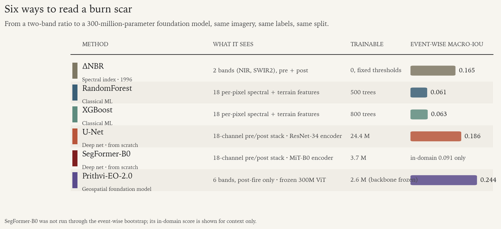

```python
# --- Meet the cast: six methods at a glance ----------------------------------
from src.viz.story_figures import fig_methods_overview

fig_methods_overview(_FIGDIR / "00_methods_overview.png")
display(Image(filename=str(_FIGDIR / "00_methods_overview.png")))
```

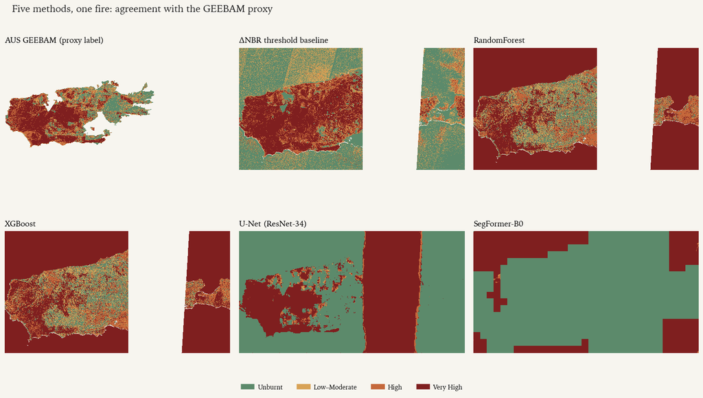

```python
# --- Five-method side-by-side severity panel ----------------------------------
preds, preds_real = model_predictions(scene)
fig, axes = plt.subplots(2, 3, figsize=(15.0, 8.5))
for ax in axes.ravel():
    ax.set_xticks([]); ax.set_yticks([])
    for s in ax.spines.values(): s.set_visible(False)
    ax.set_facecolor(PAPER)

def _title(model_key, base_title):
    if model_key not in preds:
        return f'{base_title} \u00b7 not trained'
    if not preds_real.get(model_key, False):
        return f'{base_title} \u00b7 synthetic stand-in'
    return base_title

panels = [
    ('AUS GEEBAM (proxy label)',                  scene.severity, True),
    (_title('baseline_dnbr', '\u0394NBR threshold baseline'),
        preds.get('baseline_dnbr'), 'baseline_dnbr' in preds),
    (_title('rf',            'RandomForest'),
        preds.get('rf'), 'rf' in preds),
    (_title('xgb',           'XGBoost'),
        preds.get('xgb'), 'xgb' in preds),
    (_title('unet',          'U-Net (ResNet-34)'),
        preds.get('unet'), 'unet' in preds),
    (_title('segformer',     'SegFormer-B0'),
        preds.get('segformer'), 'segformer' in preds),
]
for ax, (title, arr, present) in zip(axes.ravel(), panels):
    if arr is not None and present:
        ax.imshow(np.ma.masked_equal(arr, 255), cmap=severity_cmap(),
                  vmin=0, vmax=3, interpolation='nearest')
    else:
        ax.text(0.5, 0.5, 'not trained\n(see README for instructions)',
                ha='center', va='center', fontsize=10, color=INK_LIGHT,
                transform=ax.transAxes)
        ax.set_facecolor('#FAFAF6')
    ax.set_title(title, loc='left', fontsize=12, pad=8)

handles = [plt.Rectangle((0, 0), 1, 1, color=c) for c in SEVERITY_COLOURS]
fig.legend(handles, SEVERITY_NAMES, loc='lower center',
           bbox_to_anchor=(0.5, 0.0), ncols=4, fontsize=10,
           frameon=False, columnspacing=2.2, handletextpad=0.5)
fig.suptitle('Five methods, one fire: agreement with the GEEBAM proxy',
             fontsize=15, x=0.02, ha='left', y=0.98, color=INK)
fig.subplots_adjust(left=0.01, right=0.99, top=0.91, bottom=0.07, hspace=0.20, wspace=0.04)
plt.show()
```

## The silent killer: spatial autocorrelation

There is one mistake that breaks burn-severity benchmarks more often than any other, and it has nothing to do with the model. **Two pixels 10 metres apart on the same hillside are not independent samples.** Their soil, slope, aspect, fuel load, and the way the fire arrived at them are nearly identical. A randomly drawn validation tile inside the same fire as the training tiles is almost always closer in feature space to its training neighbours than to an unseen fire on a different continent of vegetation.

This is why every metric in the table below is computed under an **event-wise hold-out**: train on Currowan + Gospers Mountain, validate on Kangaroo Island, test on East Gippsland. No fire that contributes to training contributes to test. Where it is useful to also report the random-tile-split “vertical-slice smoke test”, those numbers are explicitly captioned as inflated.

The schematic below shows what the two protocols even are; the chart after it puts real numbers on the difference, the same models on the same Kangaroo Island scene, scored once under a leaky random-tile split and once under an honest event-wise hold-out.

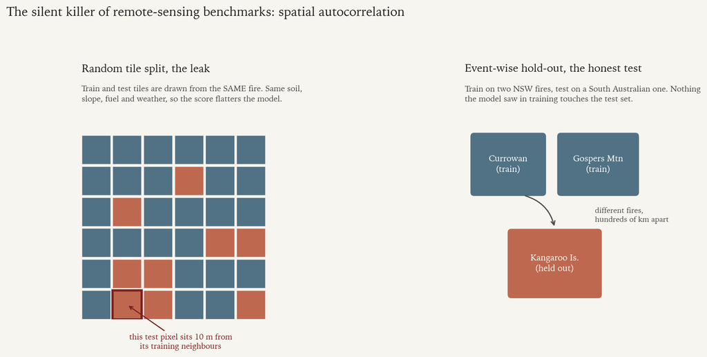

```python
# --- Why an event-wise split is the only honest one --------------------------
from src.viz.story_figures import fig_split_schematic

fig_split_schematic(_FIGDIR / "00_split_schematic.png")
display(Image(filename=str(_FIGDIR / "00_split_schematic.png")))
```

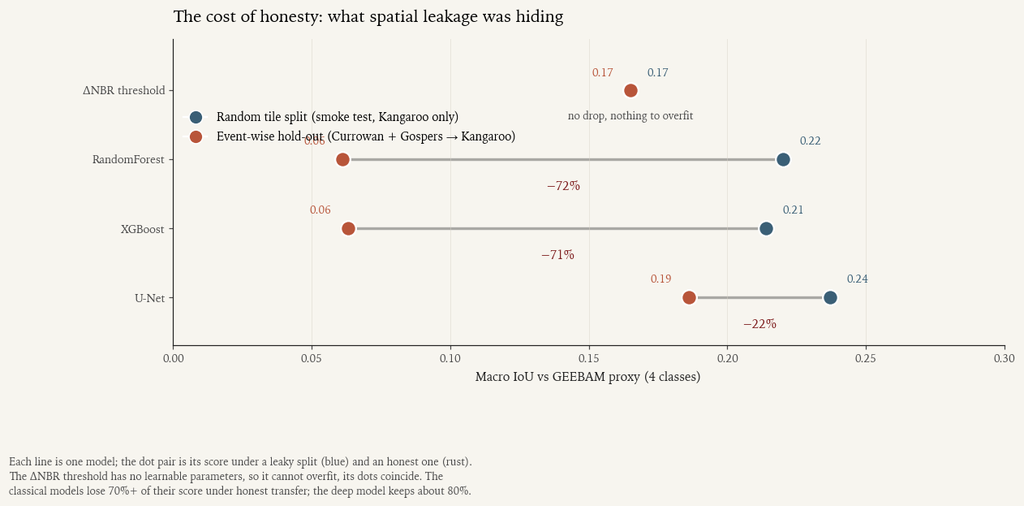

```python
# --- The cost of honesty: random-tile split vs event-wise hold-out -----------
# Real macro-IoU vs the AUS GEEBAM proxy. Random-tile split trains and tests on
# Kangaroo Island alone (spatially auto-correlated); event-wise trains on the NSW
# fires (Currowan + Gospers) and tests on Kangaroo, which the model never saw.
import numpy as np
import matplotlib.pyplot as plt
from matplotlib.lines import Line2D
from src.viz.theme import apply_theme, thin_axes, add_caption, INK_LIGHT, ACCENT, ACCENT_BLUE
apply_theme()

models = ['ΔNBR threshold', 'RandomForest', 'XGBoost', 'U-Net']
iou_random    = np.array([0.165, 0.220, 0.214, 0.237])
iou_eventwise = np.array([0.165, 0.061, 0.063, 0.186])
ys = np.arange(len(models))[::-1]

fig, ax = plt.subplots(figsize=(11.5, 5.2))
fig.subplots_adjust(left=0.16, right=0.97, top=0.86, bottom=0.20)
for y, m, r, e in zip(ys, models, iou_random, iou_eventwise):
    ax.plot([e, r], [y, y], color=INK_LIGHT, lw=2.2, alpha=0.45, zorder=1, solid_capstyle='round')
    ax.scatter(r, y, s=150, color=ACCENT_BLUE, edgecolor='white', lw=1.5, zorder=3)
    ax.scatter(e, y, s=150, color=ACCENT, edgecolor='white', lw=1.5, zorder=3)
    ax.text(r + 0.006, y + 0.17, f'{r:.2f}', fontsize=9, color=ACCENT_BLUE, ha='left', va='bottom')
    ax.text(e - 0.006, y + 0.17, f'{e:.2f}', fontsize=9, color=ACCENT, ha='right', va='bottom')
    drop = (r - e) / max(r, 1e-9)
    if drop < 0.02:
        ax.text((r + e) / 2, y - 0.28, 'no drop, nothing to overfit', ha='center', va='top',
                fontsize=8.5, color=INK_LIGHT, style='italic')
    elif drop > 0.1:
        ax.annotate(f'−{int(round(drop * 100))}%', xy=((r + e) / 2, y),
                    xytext=((r + e) / 2, y - 0.30), ha='center', va='top', fontsize=10,
                    color='#7F1F1F', fontweight='bold')
ax.set_yticks(ys); ax.set_yticklabels(models, fontsize=11.5)
ax.set_xlim(0, 0.30); ax.set_ylim(-0.7, len(models) - 0.25)
ax.set_xlabel('Macro IoU vs GEEBAM proxy (4 classes)')
ax.set_title('The cost of honesty: what spatial leakage was hiding', loc='left', fontsize=13.5, pad=14)
handles = [
    Line2D([0], [0], marker='o', color='white', markerfacecolor=ACCENT_BLUE, markersize=11,
           label='Random tile split (smoke test, Kangaroo only)'),
    Line2D([0], [0], marker='o', color='white', markerfacecolor=ACCENT, markersize=11,
           label='Event-wise hold-out (Currowan + Gospers → Kangaroo)'),
]
ax.legend(handles=handles, loc='upper left', fontsize=9.5, bbox_to_anchor=(0.0, 0.80))
thin_axes(ax); ax.grid(True, axis='x', alpha=0.5); ax.grid(False, axis='y')
add_caption(fig, 'Each line is one model; the dot pair is its score under a leaky split (blue) and an honest one (rust).\n'
                  'The ΔNBR threshold has no learnable parameters, so it cannot overfit, its dots coincide. The\n'
                  'classical models lose 70%+ of their score under honest transfer; the deep model keeps about 80%.', y=-0.04)
plt.show()
```

This is the chart a senior reviewer would actually look at, and it is the reason an event-wise hold-out is the only honest evaluation protocol for satellite-derived models that claim to generalise across fires.

When you remove the spatial leak, the classical models shed **roughly 70%** of their score. That removal, not any clever architecture, is the methodological spine of the entire benchmark.

## How big is the gap, really? Confidence intervals and a significance test

The bar chart above gives point estimates, and a point estimate invites over-reading. Before we say one model *beats* another, two questions have to be answered: **how precise is each number**, and **is the difference real or noise?**

Both are harder than they look here, because pixels in a burn map are not independent, a burnt pixel is almost always surrounded by other burnt pixels. Treating ~9 million correlated pixels as 9 million independent samples makes every difference look certain. So we resample **contiguous spatial blocks** (one tile = one block) rather than pixels: correlation is preserved inside a block, and we only assume independence between blocks. That gives an honest 95% confidence interval on macro-IoU (a bias-corrected-and-accelerated bootstrap), and a paired bootstrap on the *difference* versus the ΔNBR floor.

The result is humbling, and it is the point of the whole notebook:

```
2026-07-01 02:35:53 | INFO    | src.evaluation.uncertainty_report | skip segformer, no event-wise prediction at outputs/predictions/_event_wise_predictions/segformer_multiclass_eventwise_kangaroo.tif
```

```
2026-07-01 02:35:53 | INFO    | src.evaluation.uncertainty_report | loaded 5 models on kangaroo_island_2019_2020 (raster (2317, 4270))
```

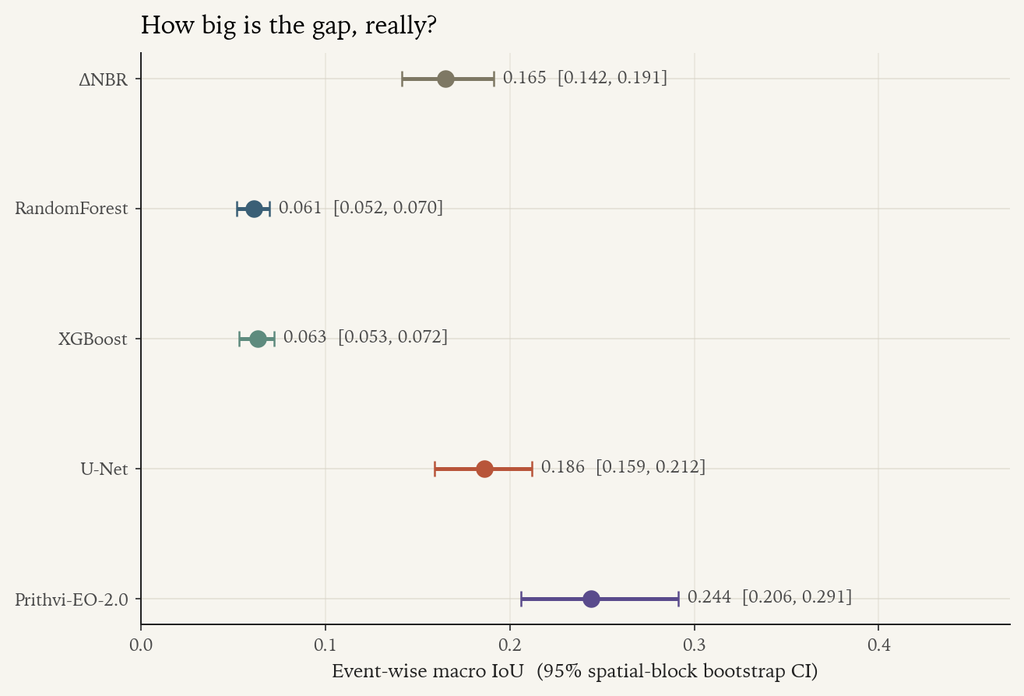

```
Paired spatial-block bootstrap, macro-IoU difference vs the ΔNBR baseline:
  RandomForest  Δ = -0.104  95% CI [-0.135, -0.072]  p = 0.000  -> significant
  XGBoost       Δ = -0.102  95% CI [-0.134, -0.069]  p = 0.000  -> significant
  U-Net         Δ = +0.022  95% CI [-0.002, +0.043]  p = 0.064  -> NOT significant (CI spans 0)
  Prithvi-EO-2.0 Δ = +0.059  95% CI [+0.031, +0.082]  p = 0.000  -> significant
```

```python
# --- Statistical rigour: spatial-block bootstrap CIs + paired significance ----
from pathlib import Path
from IPython.display import Image, display

from src.utils.geo import REPO_ROOT
from src.evaluation.uncertainty_report import (
    compute_report, fig_bootstrap_ci, fig_mcnemar,
)

_FIGDIR = REPO_ROOT / "docs" / "figures"
unc = compute_report("kangaroo_island_2019_2020", block_px=256, n_boot=2000, seed=42)

fig_bootstrap_ci(unc, _FIGDIR / "06_bootstrap_ci.png")
fig_mcnemar(unc, _FIGDIR / "07_mcnemar.png")
display(Image(filename=str(_FIGDIR / "06_bootstrap_ci.png")))

print("Paired spatial-block bootstrap, macro-IoU difference vs the ΔNBR baseline:")
for _m, _d in unc["paired_delta_vs_dnbr"].items():
    _lab = unc["models"][_m]["label"]
    _verdict = "significant" if _d["ci_low"] > 0 or _d["ci_high"] < 0 else "NOT significant (CI spans 0)"
    print(f"  {_lab:13s} Δ = {_d['delta']:+.3f}  95% CI [{_d['ci_low']:+.3f}, {_d['ci_high']:+.3f}]"
          f"  p = {_d['p_value']:.3f}  -> {_verdict}")
```

Read the forest plot honestly. The two tree models (RandomForest, XGBoost) sit far below the others, when forced to generalise to an unseen fire, pixel-wise classifiers collapse. But **U-Net's apparent win over a twenty-year-old spectral index is not statistically significant**: the paired bootstrap puts Δmacro-IoU at roughly +0.02 with a 95% interval that includes zero (p ≈ 0.06). The modern deep model does not reliably beat ΔNBR on a fire it has never seen.

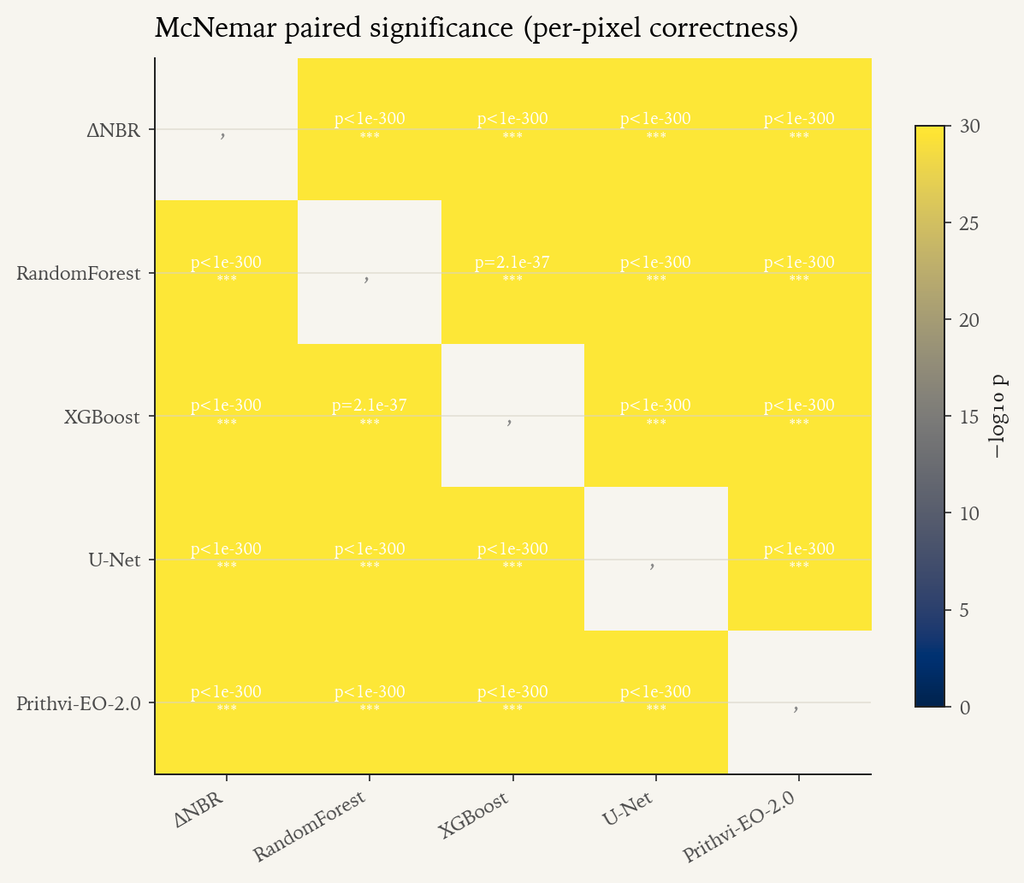

```python
display(Image(filename=str(_FIGDIR / "07_mcnemar.png")))
```

## A defensible number: design-based, area-adjusted burnt area

An ecology client does not want "macro-IoU 0.19"; they want *hectares*, and a hectare figure quoted from a map is biased whenever the map mislabels. A class the model over-predicts will have its area overstated, and the naive pixel count hides that. The standard correction is **Olofsson et al. (2014)**: weight the confusion matrix by each mapped class's area to get an unbiased area estimate, with user's / producer's accuracy and a confidence interval per class.

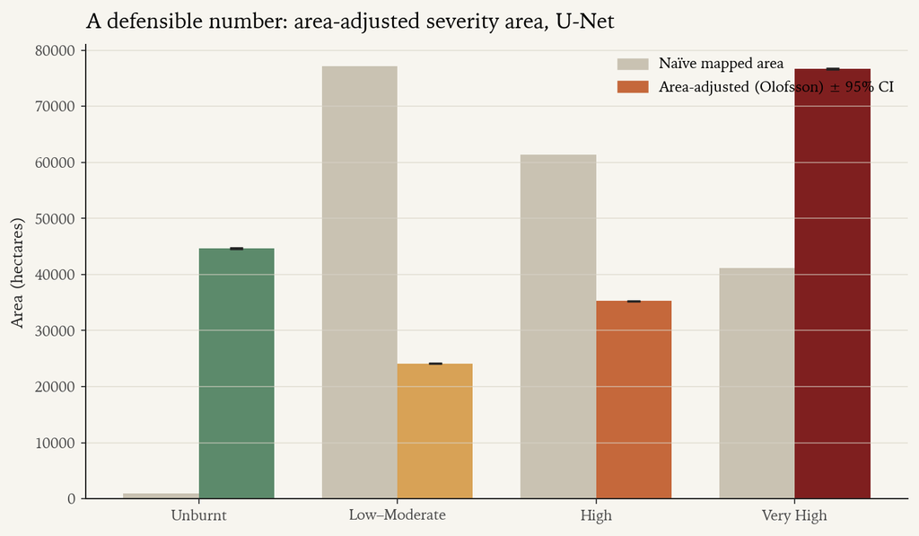

```
U-Net area-weighted overall accuracy: 0.348
  class 0: naive      953 ha  ->  adjusted    44671 ha  (U=0.31, P=0.01)
  class 1: naive    77142 ha  ->  adjusted    24125 ha  (U=0.20, P=0.64)
  class 2: naive    61423 ha  ->  adjusted    35259 ha  (U=0.25, P=0.44)
  class 3: naive    41209 ha  ->  adjusted    76672 ha  (U=0.77, P=0.42)
```

```python
# --- Area-adjusted severity area (Olofsson et al. 2014) ----------------------
from src.evaluation.uncertainty_report import fig_area_adjusted

fig_area_adjusted(unc, _FIGDIR / "08_area_adjusted.png", model="unet")
display(Image(filename=str(_FIGDIR / "08_area_adjusted.png")))

_olof = unc["models"]["unet"]["olofsson"]
print(f"U-Net area-weighted overall accuracy: {_olof['overall_accuracy']:.3f}")
for _c in _olof["per_class"]:
    print(f"  class {_c['class']}: naive {_c['area_mapped_ha']:8.0f} ha"
          f"  ->  adjusted {_c['area_adjusted_ha']:8.0f} ha"
          f"  (U={_c['users_accuracy']:.2f}, P={_c['producers_accuracy']:.2f})")
```

## Where each model fails, and why

Macro-IoU is a useful number; it is also a profoundly compressed one. Two models can land on the same macro-IoU and be wrong in completely different ways. The confusion matrices below show which class each model trades against which, and the patterns are characteristic.

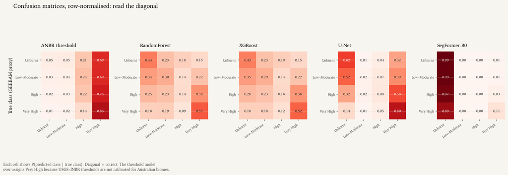

```python
# --- Confusion matrices per model ---------------------------------------------
models = [m for m in ['baseline_dnbr', 'rf', 'xgb', 'unet', 'segformer']
          if m in preds and preds_real.get(m, False)]
label_for = {'baseline_dnbr': '\u0394NBR threshold', 'rf': 'RandomForest',
             'xgb': 'XGBoost', 'unet': 'U-Net', 'segformer': 'SegFormer-B0'}

ncols = max(1, len(models))
fig, axes = plt.subplots(1, ncols, figsize=(3*ncols + 0.5, 4.5))
if ncols == 1:
    axes = [axes]
for ax, m in zip(axes, models):
    cm = confusion_matrix(preds[m], scene.severity, num_classes=4)
    row_sums = cm.sum(axis=1, keepdims=True)
    norm = np.divide(cm, np.maximum(row_sums, 1), where=row_sums > 0)
    im = ax.imshow(norm, cmap='Reds', vmin=0, vmax=1)
    ax.set_xticks(range(4)); ax.set_yticks(range(4))
    ax.set_xticklabels(SEVERITY_NAMES, fontsize=7.5, rotation=35, ha='right')
    ax.set_yticklabels(SEVERITY_NAMES, fontsize=7.5)
    ax.set_title(label_for[m], loc='left', fontsize=10.5)
    for i in range(4):
        for j in range(4):
            v = norm[i, j]
            if not np.isfinite(v): continue
            ax.text(j, i, f'{v:.2f}', ha='center', va='center',
                    fontsize=8, color='white' if v > 0.55 else INK)
    for s in ax.spines.values(): s.set_visible(False)
axes[0].set_ylabel('True class (GEEBAM proxy)', fontsize=10)
fig.suptitle('Confusion matrices, row-normalised: read the diagonal',
             fontsize=13, x=0.02, ha='left', y=1.02)
fig.tight_layout()
add_caption(fig, 'Each cell shows P(predicted class | true class). Diagonal = correct. The threshold model\n'
                  'over-assigns Very High because USGS dNBR thresholds are not calibrated for Australian biomes.', y=-0.06)
plt.show()
```

### The rare classes are where the maps actually disagree

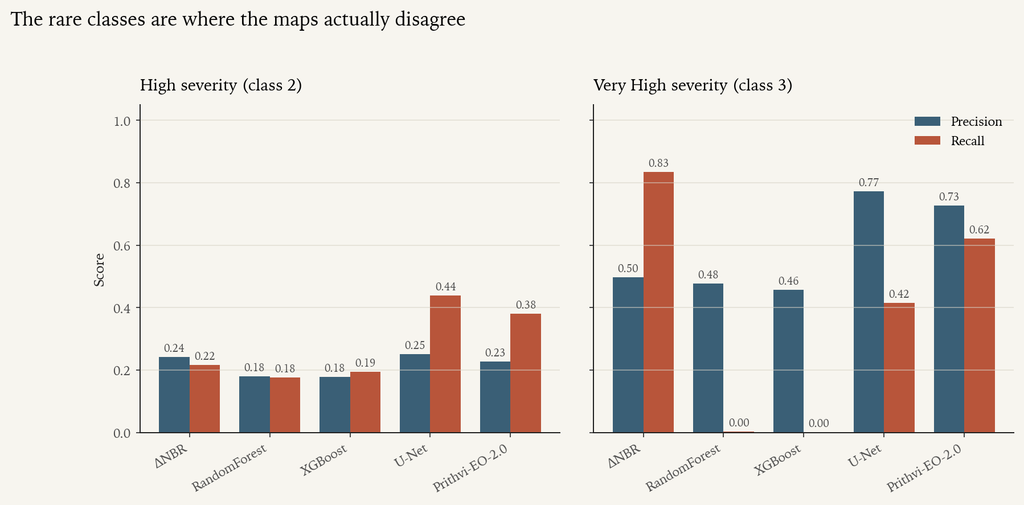

```python
# --- Rare-class precision/recall --------------------------------------------
from src.evaluation.uncertainty_report import fig_rareclass_pr

fig_rareclass_pr(unc, _FIGDIR / "08b_rareclass_pr.png")
display(Image(filename=str(_FIGDIR / "08b_rareclass_pr.png")))
```

## Why it fails: controlling for terrain, vegetation and cloud

"Where does the model fail?" is the wrong question on its own, because the factors are tangled, maybe the U-Net looks worst on steep ground only because steep ground is also where the severe classes cluster. The econometric answer is to hold the other factors fixed. We fit a logistic regression of per-pixel error on the plausible confounders, pre-fire greenness (NDVI), terrain **slope** (from a freshly-fetched Copernicus DEM, the channel that used to be a zero plane), the burn-signal magnitude (ΔNBR), and the true severity class, and read each odds ratio *all else equal*. The standard errors are **cluster-robust by spatial block**, because 9 million neighbouring pixels are not 9 million independent observations (the same correction the spatial-block bootstrap made earlier).

```
2026-07-01 02:35:56 | INFO    | src.stats.confounders | error frame: n=182492  error rate=0.606  slope=yes
```

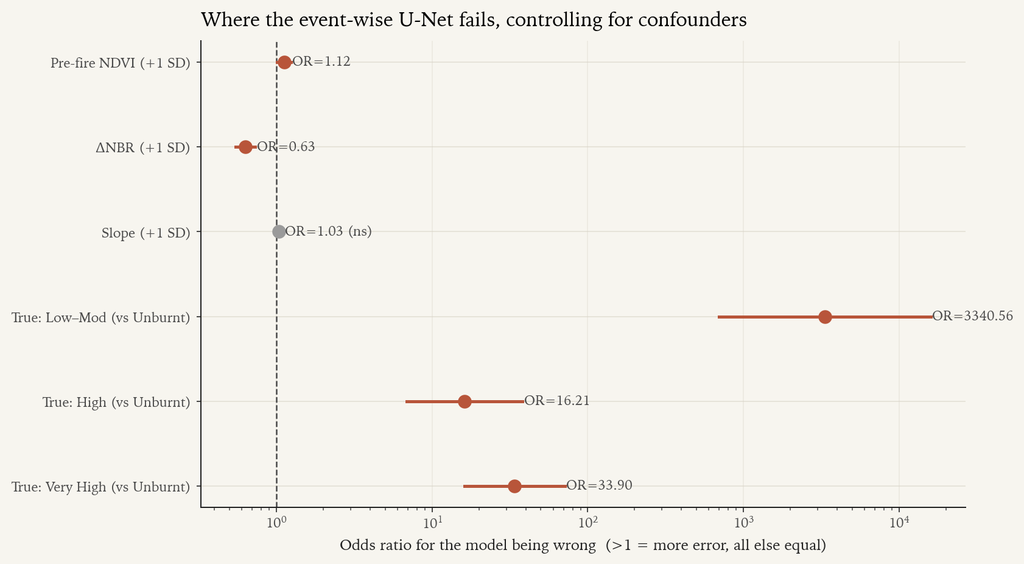

```
Odds ratio for the model being WRONG, per +1 SD, all else equal:
  pre_ndvi_z  OR=1.12  p=0.027  (significant)
  dnbr_z      OR=0.63  p=0.000  (significant)
  slope_z     OR=1.03  p=0.351  (not significant)
```

```python
# --- Confounder-controlled error analysis (cluster-robust logistic GLM) ------
import pandas as pd

from src.stats.confounders import (
    assemble_error_frame, fit_error_glm, fig_odds_ratios, odds_ratio_table,
)

edf = assemble_error_frame("kangaroo_island_2019_2020", n_sample=200_000)
glm = fit_error_glm(edf, cluster_robust=True)
fig_odds_ratios(glm, _FIGDIR / "09_confounder_glm.png")
display(Image(filename=str(_FIGDIR / "09_confounder_glm.png")))

_tab = odds_ratio_table(glm).loc[["pre_ndvi_z", "dnbr_z", "slope_z"]]
print("Odds ratio for the model being WRONG, per +1 SD, all else equal:")
for _name, _row in _tab.iterrows():
    _sig = "significant" if _row["p_value"] < 0.05 else "not significant"
    print(f"  {_name:11s} OR={_row['odds_ratio']:.2f}  p={_row['p_value']:.3f}  ({_sig})")
```

The punchline is a null result, and a useful one. Once you control for severity class and burn-signal magnitude, **slope has no significant effect on whether the model is wrong** (OR ≈ 1.0, not significant), the terrain story is a confound, not a cause. What *does* drive error is weak signal: a stronger ΔNBR makes the model markedly *less* likely to be wrong (OR ≈ 0.6 per SD), so the failures live in the ambiguous low-severity zone, not on the mountainsides. That is exactly the kind of "effect, all else equal" attribution an ecology team needs before they trust, or distrust, a map, and it is why the training/validation tiles are drawn with a spatial sampling design (`src/data/spatial_sampling.py`: spatial block-CV and stratified pixel sampling) rather than a naïve random split.

## Does this story travel? A Kangaroo-trained model on tour

The bar chart above showed what happens when we train on the two New South Wales events and validate on Kangaroo Island, the classical models collapse, the U-Net retains most of its score. What does the *inverse* look like?

The models loaded here were trained only on Kangaroo Island (the vertical-slice configuration). The figure below applies them, unchanged and without fine-tuning, to two NSW fire complexes the network has never seen, **Currowan** (sclerophyll forest on the south coast, ~500,000 ha) and **Gospers Mountain** (eucalypt forest north-west of Sydney, the single largest forest fire in modern Australian record at ~1.5 million ha).

Three rows. From left to right: the post-fire scene as the satellite sees it in SWIR / NIR false colour, the AUS GEEBAM proxy label, the ΔNBR threshold, and the U-Net. The macro-IoU printed under each prediction is the agreement against GEEBAM for that AOI.

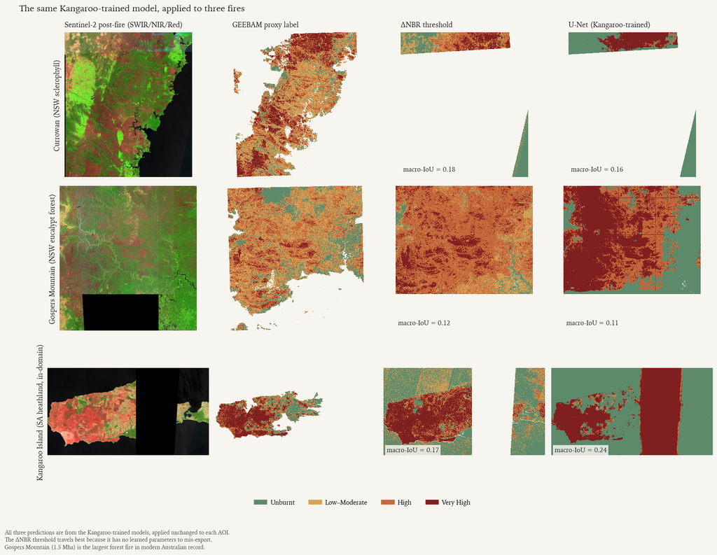

```python
# --- Out-of-domain travel: Kangaroo-trained model -> NSW eucalypt forests -------
import json as _json
import rasterio as _rio
import numpy as _np
import matplotlib.pyplot as _plt
from pathlib import Path as _Path

from src.utils.geo import REPO_ROOT
from src.viz.synthetic_scene import s2_swir_falsecolour
from src.viz.theme import (SEVERITY_COLOURS, SEVERITY_NAMES, INK, INK_LIGHT,
                           PAPER, severity_cmap, add_caption)

AOIS = [
    ("currowan_2019_2020",        "Currowan (NSW sclerophyll)"),
    ("gospers_mountain_2019_2020","Gospers Mountain (NSW eucalypt forest)"),
    ("kangaroo_island_2019_2020", "Kangaroo Island (SA heathland, in-domain)"),
]
COLUMNS = [
    ("post_swir", "Sentinel-2 post-fire (SWIR/NIR/Red)"),
    ("label",     "GEEBAM proxy label"),
    ("dnbr",      "\u0394NBR threshold"),
    ("unet",      "U-Net (Kangaroo-trained)"),
]

def _read1(p):
    with _rio.open(p) as ds:
        return ds.read(1)

def _read_stack(p):
    with _rio.open(p) as ds:
        return ds.read().astype(_np.float32)

scores = _json.loads((REPO_ROOT / "outputs/metrics/per_aoi_summary.json").read_text())

fig, axes = _plt.subplots(3, 4, figsize=(15.5, 11.0))
for ax in axes.ravel():
    ax.set_xticks([]); ax.set_yticks([])
    for s in ax.spines.values():
        s.set_visible(False)

for r, (ev, row_title) in enumerate(AOIS):
    interim = REPO_ROOT / "data" / "interim" / ev
    post = _read_stack(interim / "post_stack_10m.tif")
    label = _read1(interim / "label_10m.tif")

    swir = s2_swir_falsecolour(_np.nan_to_num(post, nan=0.0))
    axes[r, 0].imshow(swir)
    axes[r, 0].set_ylabel(row_title, fontsize=11, color=INK)

    axes[r, 1].imshow(_np.ma.masked_equal(label, 255),
                      cmap=severity_cmap(), vmin=0, vmax=3, interpolation="nearest")

    dnbr_path = REPO_ROOT / f"outputs/predictions/baseline_dnbr/{ev}/multiclass.tif"
    if dnbr_path.exists():
        d = _read1(dnbr_path)
        axes[r, 2].imshow(_np.ma.masked_equal(d, 255),
                          cmap=severity_cmap(), vmin=0, vmax=3, interpolation="nearest")
        iou = scores.get(ev, {}).get("baseline_dnbr", {}).get("macro_iou")
        if iou is not None:
            axes[r, 2].text(0.02, 0.04, f"macro-IoU = {iou:.2f}", transform=axes[r, 2].transAxes,
                            fontsize=10, color=INK,
                            bbox=dict(facecolor=PAPER, alpha=0.85, edgecolor="none", pad=2.5))

    unet_path = REPO_ROOT / f"outputs/predictions/unet_multiclass/{ev}.tif"
    if unet_path.exists():
        u = _read1(unet_path)
        axes[r, 3].imshow(_np.ma.masked_equal(u, 255),
                          cmap=severity_cmap(), vmin=0, vmax=3, interpolation="nearest")
        iou = scores.get(ev, {}).get("unet", {}).get("macro_iou")
        if iou is not None:
            axes[r, 3].text(0.02, 0.04, f"macro-IoU = {iou:.2f}", transform=axes[r, 3].transAxes,
                            fontsize=10, color=INK,
                            bbox=dict(facecolor=PAPER, alpha=0.85, edgecolor="none", pad=2.5))

for c, (_, col_title) in enumerate(COLUMNS):
    axes[0, c].set_title(col_title, fontsize=11, loc="left", color=INK, pad=8)

handles = [_plt.Rectangle((0, 0), 1, 1, color=c) for c in SEVERITY_COLOURS]
fig.legend(handles, SEVERITY_NAMES, loc="lower center",
           bbox_to_anchor=(0.5, -0.005), ncols=4, fontsize=10,
           frameon=False, columnspacing=2.2, handletextpad=0.5)

fig.suptitle("The same Kangaroo-trained model, applied to three fires",
             fontsize=14, x=0.02, ha="left", y=0.995, color=INK)
fig.subplots_adjust(left=0.06, right=0.99, top=0.94, bottom=0.05,
                    hspace=0.06, wspace=0.04)
add_caption(fig,
            "All three predictions are from the Kangaroo-trained models, applied unchanged to each AOI.\n"
            "The \u0394NBR threshold travels best because it has no learned parameters to mis-export.\n"
            "Gospers Mountain (1.5 Mha) is the largest forest fire in modern Australian record.",
            y=-0.04)
_plt.show()
```